# Multilevel and Panel Data and Bayesian Statistics (ECON/POLISCI 151, Week 7 Section)

Albert Chiu

## Data with Structure

This week will introduce models for multilevel and panel data. Each of these types of data have unique structures for which you may need to account. Many of the models we will consider today will be a sort middle ground between the setting where all observations belong to the lower level and we treat them as independent (which gives us the largest effective N, but which may not be a realistic assumption) and the setting where all observations are agglomerated into a higher level (which gives us the smallest effective N, but which allows arbitrary dependence between lower level units).

## Multi-level Modelling

Sometimes our data has multiple “levels,” e.g., each observation is a student, who belongs to a class, which is part of a school. For our example, we will use data from LAPOP. Each observation is a respondent, and each respondent lives in a province, which in turn belongs to a country.

```r
load("cleaned_data.RData")
df2010 <- df[df$wave==2010, ]  # subset to observations from the 2010 survey wave
colnames(df2010)
```

```
##  [1] "country"              "prov"                 "wave"
##  [4] "year"                 "office"               "marriage"
##  [7] "education"            "age"                  "rel_importance"
## [10] "evangelical"          "ideology"             "rural"
## [13] "poli_attendance"      "household_income"     "news"
## [16] "male"                 "weight1500"           "household_income_old"
## [19] "household_income_new" "cname"                "legal_marry"
## [22] "legal_marry_lag1"     "legal_union"          "legal_union_lag1"
## [25] "LARI"                 "LARI_lead1"           "LARI_lag0"
## [28] "LARI_lag1"            "LARI_lag2"            "LARI_lag3"
## [31] "LARI_lag4"            "LARI_lag5"            "adm_office"
## [34] "adm_marriage"
```

```r
cyr2010 <- cyr[cyr$wave==2010, ]  # aggregated to country-year
```

Our outcome of interest will be the variable `marriage`, which is the respondent’s approval of same-sex marraige (10=strongly approve, 1=strongly disapprove). Consider the two extreme models, one where we ignore the country and one where we aggregate to the country level, that estimate the relationship between religiosity and approval.

```r
## individual observations
m1 <- lm(marriage ~ rel_importance, data=df2010)
## aggregated to country level
m2 <- lm(marriage ~ rel_importance, data=cyr2010)

confint(m1)  # much tighter
```

```
##                    2.5 %    97.5 %
## (Intercept)    2.0797690 2.2295725
## rel_importance 0.7584374 0.8389646
```

```r
confint(m2)
```

```
##                    2.5 %    97.5 %
## (Intercept)    -2.770279 0.8421447
## rel_importance  1.637191 3.7866935
```

Notice that the confidence interval is much tighter for the first model. This is because the N is much larger. These are asking fundamentally different questions (effect of an individual’s religiousity on her approval vs. effect of country-year average religiosity on average approval), but in a sense the latter is a bit more flexible. The former assumes constant effects of religiosity on each individual’s approval, while the latter only assumes constant effects of an average on an average. Note that the former assumption implies the latter, but the latter does not imply the former. The latter model allows effects to be arbitrarily heterogeneous accross individuals, so long as the aggregated effects end up being constant.

Multilevel models can be a middle ground between the two, allowing for specific forms of heterogeneity. E.g., the slope can vary additivly by country.

```r
m3 <- lme4::lmer(marriage ~ LARI + (0 + LARI | country), data=df2010)
summary(m3)
```

```
## Linear mixed model fit by REML ['lmerMod']
## Formula: marriage ~ LARI + (0 + LARI | country)
##    Data: df2010
##
## REML criterion at convergence: 146098.8
##
## Scaled residuals:
##     Min      1Q  Median      3Q     Max
## -1.7366 -0.6807 -0.4562  0.6513  2.6996
##
## Random effects:
##  Groups   Name Variance Std.Dev.
##  country  LARI 0.2583   0.5082
##  Residual      8.9307   2.9884
## Number of obs: 29042, groups:  country, 17
##
## Fixed effects:
##             Estimate Std. Error t value
## (Intercept)   2.9190     0.4906   5.950
## LARI          0.1810     0.2718   0.666
##
## Correlation of Fixed Effects:
##      (Intr)
## LARI -0.890
```

There are a number of ways to fit this model. The `lme4` package uses mixed effects models, which are composed of “fixed effects” and “random effects.”

```r
## some minor variations
# random intercept
lme4::lmer(marriage ~ LARI + (1 + LARI | country), data=df2010)
```

```
## Linear mixed model fit by REML ['lmerMod']
## Formula: marriage ~ LARI + (1 + LARI | country)
##    Data: df2010
## REML criterion at convergence: 146089
## Random effects:
##  Groups   Name        Std.Dev. Corr
##  country  (Intercept) 2.470
##           LARI        1.056    -0.99
##  Residual             2.988
## Number of obs: 29042, groups:  country, 17
## Fixed Effects:
## (Intercept)         LARI
##      1.2705       0.7601
```

```r
lme4::lmer(marriage ~ LARI + (LARI | country), data=df2010)
```

```
## Linear mixed model fit by REML ['lmerMod']
## Formula: marriage ~ LARI + (LARI | country)
##    Data: df2010
## REML criterion at convergence: 146089
## Random effects:
##  Groups   Name        Std.Dev. Corr
##  country  (Intercept) 2.470
##           LARI        1.056    -0.99
##  Residual             2.988
## Number of obs: 29042, groups:  country, 17
## Fixed Effects:
## (Intercept)         LARI
##      1.2705       0.7601
```

```r
# random intercept independent of slope
lme4::lmer(marriage ~ LARI + (1 | country) + (0 + LARI | country), data=df2010)
```

```
## Linear mixed model fit by REML ['lmerMod']
## Formula: marriage ~ LARI + (1 | country) + (0 + LARI | country)
##    Data: df2010
## REML criterion at convergence: 146092.3
## Random effects:
##  Groups    Name        Std.Dev.
##  country   (Intercept) 0.8892
##  country.1 LARI        0.1148
##  Residual              2.9884
## Number of obs: 29042, groups:  country, 17
## Fixed Effects:
## (Intercept)         LARI
##      1.9819       0.5961
```

## Bayesian Statistics

Another way of doing multilevel modelling is using Bayesian statistics. In general, Bayesians assume that there is a prior distribution over the parameters and a distribution of the data given the parameters (likelihood), and combine these to get a posterior.

### `brms`

```r
df2010_unlabelled <- apply(df2010, MARGIN=2, as.numeric)
out_brm <- brms::brm(marriage ~ LARI + (1 + LARI | country),
                     data=df2010_unlabelled[sample(nrow(df2010), 1000), ])
```

[output not shown]

[output cut: 93 more lines]

[output not shown]

```r
summary(out_brm)
```

```
## Warning: Parts of the model have not converged (some Rhats are > 1.05). Be
## careful when analysing the results! We recommend running more iterations and/or
## setting stronger priors.

## Warning: There were 346 divergent transitions after warmup. Increasing
## adapt_delta above 0.8 may help. See http://mc-stan.org/misc/
## warnings.html#divergent-transitions-after-warmup

##  Family: gaussian
##   Links: mu = identity; sigma = identity
## Formula: marriage ~ LARI + (1 + LARI | country)
##    Data: df2010_unlabelled[sample(nrow(df2010), 1000), ] (Number of observations: 949)
##   Draws: 4 chains, each with iter = 2000; warmup = 1000; thin = 1;
##          total post-warmup draws = 4000
##
## Group-Level Effects:
## ~country (Number of levels: 17)
##                     Estimate Est.Error l-95% CI u-95% CI Rhat Bulk_ESS Tail_ESS
## sd(Intercept)           0.72      0.48     0.03     2.01 1.07      100       34
## sd(LARI)                0.33      0.22     0.02     0.88 1.08       41       50
## cor(Intercept,LARI)    -0.26      0.58    -0.98     0.89 1.05       75       49
##
## Population-Level Effects:
##           Estimate Est.Error l-95% CI u-95% CI Rhat Bulk_ESS Tail_ESS
## Intercept     2.01      0.58     0.90     3.12 1.02      237     2095
## LARI          0.59      0.25     0.10     1.04 1.03      173      363
##
## Family Specific Parameters:
##       Estimate Est.Error l-95% CI u-95% CI Rhat Bulk_ESS Tail_ESS
## sigma     3.04      0.07     2.91     3.18 1.02     2873     1647
##
## Draws were sampled using sampling(NUTS). For each parameter, Bulk_ESS
## and Tail_ESS are effective sample size measures, and Rhat is the potential
## scale reduction factor on split chains (at convergence, Rhat = 1).
```

### `rstan`

One of the most flexibe ways of fitting Bayesian models is to use `rstan`. Stan models are infinitely customizable and more transparent than `brms`.

#### Simple model

```r
N <- 100

set.seed(123)
mu <- rnorm(N)
sigma <- abs(rcauchy(N))
y <- rnorm(N, mean=mu, sd=sigma)

simple <-"
//
// This Stan program defines a simple model, with a
// vector of values 'y' modeled as normally distributed
// with mean 'mu' and standard deviation 'sigma'.
//

// The input data is a vector 'y' of length 'N'.
data {
  int<lower=0> N;
  vector[N] y;
}

// The parameters accepted by the model. Our model
// accepts two parameters 'mu' and 'sigma'.
parameters {
  real mu;
  real<lower=0> sigma;
}

// The model to be estimated. We model the output
// 'y' to be normally distributed with mean 'mu'
// and standard deviation 'sigma'.
model {
  y ~ normal(mu, sigma);
}
"

dat <- list("N"=N, "y"=y)

out_simple <- rstan::stan(model_code=simple, data=dat, verbose = F)
```

[output not shown]

```r
print(out_simple)
```

```
## Inference for Stan model: 9d111088d7e6f1c47e3c963d5d71e6bb.
## 4 chains, each with iter=2000; warmup=1000; thin=1;
## post-warmup draws per chain=1000, total post-warmup draws=4000.
##
##          mean se_mean   sd    2.5%     25%     50%     75%   97.5% n_eff Rhat
## mu      -1.42    0.03 1.51   -4.36   -2.41   -1.41   -0.43    1.57  2650    1
## sigma   15.23    0.02 1.09   13.29   14.46   15.15   15.93   17.51  3474    1
## lp__  -318.65    0.02 0.99 -321.22 -319.03 -318.34 -317.95 -317.69  1626    1
##
## Samples were drawn using NUTS(diag_e) at Fri May 13 11:35:21 2022.
## For each parameter, n_eff is a crude measure of effective sample size,
## and Rhat is the potential scale reduction factor on split chains (at
## convergence, Rhat=1).
```

```r
print(out_simple)
```

```
## Inference for Stan model: 9d111088d7e6f1c47e3c963d5d71e6bb.
## 4 chains, each with iter=2000; warmup=1000; thin=1;
## post-warmup draws per chain=1000, total post-warmup draws=4000.
##
##          mean se_mean   sd    2.5%     25%     50%     75%   97.5% n_eff Rhat
## mu      -1.42    0.03 1.51   -4.36   -2.41   -1.41   -0.43    1.57  2650    1
## sigma   15.23    0.02 1.09   13.29   14.46   15.15   15.93   17.51  3474    1
## lp__  -318.65    0.02 0.99 -321.22 -319.03 -318.34 -317.95 -317.69  1626    1
##
## Samples were drawn using NUTS(diag_e) at Fri May 13 11:35:21 2022.
## For each parameter, n_eff is a crude measure of effective sample size,
## and Rhat is the potential scale reduction factor on split chains (at
## convergence, Rhat=1).
```

#### Simple Regression

```r
simple_reg <- "
data {
  int<lower=0> N;
  vector[N] y;
  vector[N] x;
}

parameters {
  real<lower=0> sigma;
  real beta;
}

model {
  y ~ normal(x*beta, sigma);
}

generated quantities {
  real sim_y;
  sim_y = beta*100; // value of y if x=100
}
"

x <- rnorm(N)
beta <- rnorm(N)
y <- x*beta

out_simple_reg <- rstan::stan(model_code=simple_reg,
                              data=list("N"=N, "y"=y, "x"=x), verbose=F)
```

[output not shown]

```r
print(out_simple_reg)
```

```
## Inference for Stan model: f0f230962e09cf3cbc6a6f02b3d4e46f.
## 4 chains, each with iter=2000; warmup=1000; thin=1;
## post-warmup draws per chain=1000, total post-warmup draws=4000.
##
##         mean se_mean   sd   2.5%    25%    50%    75%  97.5% n_eff Rhat
## sigma   0.96    0.00 0.07   0.84   0.91   0.96   1.00   1.10  3721    1
## beta   -0.09    0.00 0.10  -0.28  -0.15  -0.09  -0.02   0.10  3118    1
## sim_y  -8.78    0.17 9.59 -27.70 -15.08  -8.90  -2.31   9.73  3118    1
## lp__  -45.38    0.03 1.02 -48.14 -45.72 -45.06 -44.68 -44.43  1610    1
##
## Samples were drawn using NUTS(diag_e) at Fri May 13 11:35:35 2022.
## For each parameter, n_eff is a crude measure of effective sample size,
## and Rhat is the potential scale reduction factor on split chains (at
## convergence, Rhat=1).
```

#### Multilevel Regression

```r
simple_ml <- "
data {
  int<lower=0> N;
  vector[N] y;
  vector[N] x;
  int<lower=0> G;  // number of groups
  int<lower=1, upper=G> group[N];  // ID for group
}

parameters {
  real<lower=0> sigma;  // variance for response

  real beta;
  real<lower=0> sigma_b;  // variance for slope

  vector[G] beta_g;  // group-specific component of slope
  real<lower=0> sigma_bg;  // variance for group-specific slope
}

model {
  sigma ~ gamma(2, .1);  // prior

  sigma_b ~ cauchy(0, 2.5); // hyperprior
  beta ~ normal(0, sigma_b);

  sigma_bg ~ cauchy(0, 2.5); // hyperprior
  for (g in 1:G) {
    beta_g[g] ~ normal(0, sigma_bg);  // prior
  }

{  // variable declarations have to come at top of block
  vector[N] mu;
  for (i in 1:N) {
    mu[i] = (beta + beta_g[group[i]])*x[i];
  }
  y ~ normal(mu, sigma);
}

}
"

group <- rep(1:5, each=N/5)
out_simple_ml <- rstan::stan(model_code=simple_ml,
                             data=list("N"=N, "y"=y, "x"=x,
                                       "G"=5, "group"=group),
                             verbose=F)
```

[output not shown]

```r
print(out_simple_ml)
```

```
## Inference for Stan model: b33f42eeb9a9bfc015be87b259869ed9.
## 4 chains, each with iter=2000; warmup=1000; thin=1;
## post-warmup draws per chain=1000, total post-warmup draws=4000.
##
##             mean se_mean   sd   2.5%    25%    50%    75%  97.5% n_eff Rhat
## sigma       0.95    0.00 0.07   0.83   0.90   0.95   1.00   1.11  1827 1.00
## beta        0.00    0.02 0.23  -0.34  -0.11  -0.02   0.06   0.48   188 1.02
## sigma_b     1.18    0.08 3.04   0.02   0.17   0.45   1.22   5.95  1485 1.00
## beta_g[1]  -0.23    0.02 0.27  -0.83  -0.34  -0.19  -0.07   0.11   200 1.02
## beta_g[2]   0.05    0.02 0.26  -0.44  -0.05   0.04   0.17   0.53   283 1.01
## beta_g[3]  -0.05    0.02 0.26  -0.60  -0.14  -0.02   0.07   0.35   223 1.01
## beta_g[4]   0.15    0.01 0.27  -0.30   0.01   0.12   0.29   0.71   395 1.01
## beta_g[5]  -0.04    0.02 0.26  -0.58  -0.13  -0.01   0.08   0.38   243 1.02
## sigma_bg    0.30    0.02 0.27   0.04   0.14   0.24   0.38   0.99   198 1.02
## lp__      -40.76    0.20 3.14 -47.73 -42.56 -40.52 -38.73 -35.04   250 1.02
##
## Samples were drawn using NUTS(diag_e) at Fri May 13 11:35:50 2022.
## For each parameter, n_eff is a crude measure of effective sample size,
## and Rhat is the potential scale reduction factor on split chains (at
## convergence, Rhat=1).
```

```r
set.seed(123)
keep <- complete.cases(df2010[, c("marriage", "rel_importance", "country")])
sub_df2010 <- df2010[keep, ] %>%
  .[sample(nrow(.), 1000), ]
out_simple_ml_LAPOP <- rstan::stan(model_code=simple_ml,
                             data=list("N"=nrow(sub_df2010),
                                       "y"=sub_df2010$marriage,
                                       "x"=sub_df2010$rel_importance,
                                       "G"=length(unique(sub_df2010$country)),
                                       "group"=as.numeric(factor(sub_df2010$country))),
                             verbose=F)
print(out_simple_ml_LAPOP)
```

```
## Inference for Stan model: b33f42eeb9a9bfc015be87b259869ed9.
## 4 chains, each with iter=2000; warmup=1000; thin=1;
## post-warmup draws per chain=1000, total post-warmup draws=4000.
##
##                mean se_mean   sd     2.5%      25%      50%      75%    97.5%
## sigma          3.10    0.00 0.07     2.98     3.06     3.10     3.15     3.24
## beta           1.74    0.00 0.15     1.44     1.64     1.74     1.83     2.03
## sigma_b        3.40    0.10 4.45     0.82     1.54     2.33     3.75    12.29
## beta_g[1]      0.55    0.01 0.26     0.03     0.38     0.55     0.72     1.07
## beta_g[2]     -0.02    0.00 0.28    -0.55    -0.20    -0.02     0.17     0.54
## beta_g[3]     -0.51    0.01 0.27    -1.05    -0.71    -0.51    -0.33     0.02
## beta_g[4]     -0.04    0.01 0.26    -0.53    -0.21    -0.04     0.14     0.47
## beta_g[5]     -0.38    0.01 0.28    -0.94    -0.56    -0.37    -0.19     0.16
## beta_g[6]     -0.48    0.00 0.23    -0.93    -0.63    -0.47    -0.32    -0.05
## beta_g[7]      0.11    0.00 0.25    -0.39    -0.05     0.11     0.28     0.60
## beta_g[8]      0.20    0.01 0.25    -0.27     0.03     0.20     0.37     0.68
## beta_g[9]     -0.35    0.00 0.20    -0.76    -0.49    -0.35    -0.22     0.05
## beta_g[10]    -0.04    0.00 0.22    -0.49    -0.19    -0.04     0.11     0.40
## beta_g[11]     0.10    0.01 0.25    -0.38    -0.07     0.09     0.26     0.60
## beta_g[12]    -0.13    0.00 0.26    -0.65    -0.31    -0.13     0.04     0.38
## beta_g[13]     0.39    0.01 0.21    -0.01     0.24     0.38     0.52     0.81
## beta_g[14]    -0.21    0.00 0.20    -0.61    -0.34    -0.21    -0.08     0.18
## beta_g[15]     1.09    0.01 0.24     0.63     0.92     1.08     1.25     1.58
## beta_g[16]    -0.64    0.00 0.23    -1.10    -0.78    -0.63    -0.49    -0.19
## beta_g[17]     0.55    0.01 0.23     0.10     0.40     0.55     0.70     1.02
## sigma_bg       0.54    0.00 0.13     0.34     0.45     0.52     0.61     0.82
## lp__       -1628.42    0.09 3.44 -1636.22 -1630.46 -1628.10 -1626.01 -1622.80
##            n_eff Rhat
## sigma       5977    1
## beta         999    1
## sigma_b     1940    1
## beta_g[1]   2261    1
## beta_g[2]   3291    1
## beta_g[3]   2685    1
## beta_g[4]   2588    1
## beta_g[5]   2677    1
## beta_g[6]   2150    1
## beta_g[7]   2636    1
## beta_g[8]   2341    1
## beta_g[9]   1958    1
## beta_g[10]  2004    1
## beta_g[11]  2442    1
## beta_g[12]  2813    1
## beta_g[13]  1720    1
## beta_g[14]  1751    1
## beta_g[15]  2162    1
## beta_g[16]  2141    1
## beta_g[17]  2109    1
## sigma_bg    2820    1
## lp__        1409    1
##
## Samples were drawn using NUTS(diag_e) at Fri May 13 11:35:57 2022.
## For each parameter, n_eff is a crude measure of effective sample size,
## and Rhat is the potential scale reduction factor on split chains (at
## convergence, Rhat=1).
```

```
## ci_level: 0.8 (80% intervals)

## outer_level: 0.95 (95% intervals)
```

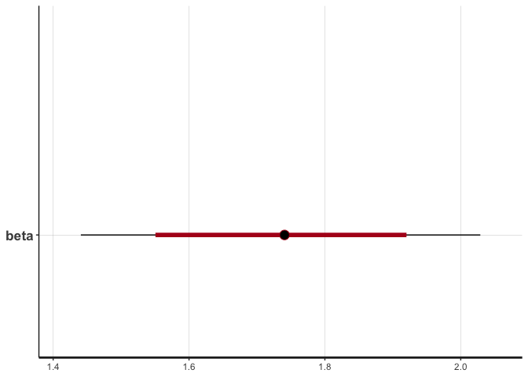

```r
rstan::plot(out_simple_ml_LAPOP, pars="beta")
```

```
## ci_level: 0.8 (80% intervals)

## outer_level: 0.95 (95% intervals)
```

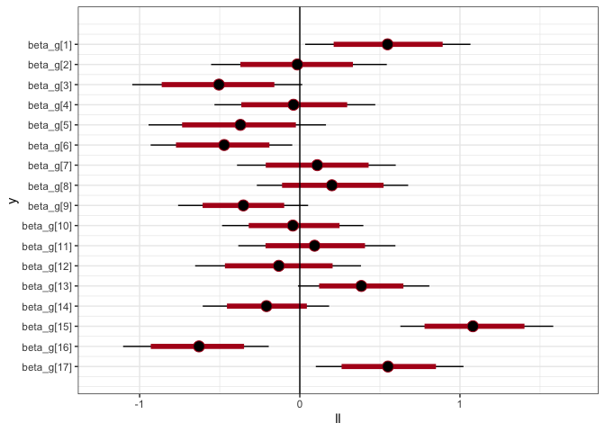

```r
rstan::plot(out_simple_ml_LAPOP, pars=paste0("beta_g[", 1:17, "]")) +
  ggplot2::geom_vline(xintercept=0) +
  ggplot2::theme_bw()
```

#### Multilevel Model with Time Dimension

The main independent variable of interest is the `LARI`, which is an index of the number of LGBTQ rights in that country-year. We allow the slope to vary additively by country and year. Religious importance is now a control instead, along with an indicator for evangelicalism, and their slopes are constant.

```r
set.seed(123)
keep <- complete.cases(df[, c("marriage", "rel_importance", "evangelical", "LARI", "country", "year")])
sub_df<- df[keep, ] %>%
  .[sample(nrow(.), 1000), ]
dat <- list(y = sub_df$marriage,
            x = sub_df[, c("rel_importance", "evangelical")],
            d = sub_df$LARI,
            gg = as.numeric(factor(sub_df$country)),  # group
            tt = as.numeric(factor(sub_df$year)),  # time
            Ti = length(unique(sub_df$year)),  # number of time periods
            G = length(unique(sub_df$country)),  # number of groups
            N = nrow(sub_df),
            K = 2)  # number of controls
out_ml <- rstan::stan(file="multilevel.stan", data = dat,
                      seed=123, iter=2000, cores = 4, chains = 4)
```

[output not shown]

```r
print(out_ml)
```

```
## Inference for Stan model: multilevel.
## 4 chains, each with iter=2000; warmup=1000; thin=1;
## post-warmup draws per chain=1000, total post-warmup draws=4000.
##
##                   mean se_mean     sd     2.5%      25%      50%      75%
## alpha_G[1]     -122.48  183.48 329.19  -611.47  -391.28  -196.89   170.81
## alpha_G[2]     -124.02  183.51 329.23  -613.77  -392.60  -198.42   169.46
## alpha_G[3]     -124.85  183.47 329.18  -614.25  -393.17  -198.96   169.08
## alpha_G[4]     -123.60  183.51 329.26  -612.33  -392.03  -197.75   170.33
## alpha_G[5]     -124.08  183.52 329.29  -613.22  -393.33  -198.46   169.72
## alpha_G[6]     -124.12  183.54 329.32  -612.42  -393.71  -198.69   170.23
## alpha_G[7]     -124.32  183.44 329.14  -614.40  -393.33  -198.50   169.57
## alpha_G[8]     -121.43  183.49 329.21  -611.76  -390.14  -195.74   172.47
## alpha_G[9]     -125.31  183.45 329.15  -613.60  -395.09  -199.08   167.87
## alpha_G[10]    -124.02  183.49 329.19  -612.94  -392.82  -197.83   169.11
## alpha_G[11]    -123.65  183.45 329.14  -611.50  -392.30  -197.41   169.84
## alpha_G[12]    -124.26  183.47 329.20  -613.92  -393.13  -198.76   169.77
## alpha_G[13]    -122.69  183.45 329.18  -612.63  -391.59  -196.26   171.17
## alpha_G[14]    -125.22  183.39 329.08  -614.25  -394.46  -198.75   167.29
## alpha_G[15]    -123.86  183.46 329.15  -613.83  -392.90  -197.55   169.84
## alpha_G[16]    -124.48  183.49 329.19  -614.71  -393.15  -198.18   168.83
## alpha_G[17]    -121.90  183.50 329.14  -612.68  -391.41  -195.60   171.41
## alpha_T[1]      126.19  183.49 329.22  -534.53  -167.71   200.17   394.89
## alpha_T[2]      125.90  183.49 329.22  -534.52  -168.05   200.09   394.29
## alpha_T[3]      125.97  183.48 329.20  -534.66  -168.50   200.16   394.42
## alpha_T[4]      127.60  183.47 329.18  -532.61  -166.28   202.22   396.11
## alpha_T[5]      126.15  183.46 329.18  -534.48  -167.09   199.87   394.99
## mu_raw            0.23    0.03   0.54    -0.82    -0.02     0.16     0.46
## sigma_mu_unif     0.00    0.03   0.48    -1.06    -0.25     0.01     0.26
## tau_G_raw[1]     -0.14    0.04   0.88    -1.90    -0.71    -0.14     0.43
## tau_G_raw[2]      0.10    0.04   0.99    -1.77    -0.58     0.08     0.77
## tau_G_raw[3]     -0.04    0.04   0.99    -1.95    -0.72    -0.02     0.63
## tau_G_raw[4]     -0.63    0.04   0.94    -2.44    -1.27    -0.65    -0.01
## tau_G_raw[5]     -0.01    0.04   1.01    -1.93    -0.69    -0.04     0.68
## tau_G_raw[6]     -0.03    0.04   1.01    -2.02    -0.71    -0.03     0.67
## tau_G_raw[7]      0.00    0.04   1.01    -2.00    -0.67     0.02     0.67
## tau_G_raw[8]     -0.89    0.03   0.67    -2.36    -1.29    -0.84    -0.44
## tau_G_raw[9]      0.24    0.04   0.86    -1.43    -0.33     0.28     0.82
## tau_G_raw[10]     0.17    0.03   0.75    -1.32    -0.33     0.17     0.65
## tau_G_raw[11]    -0.22    0.04   0.88    -1.95    -0.79    -0.22     0.35
```

[output cut: 112 more lines]

```
## tau_G[14]         1.82   440 1.01
## tau_G[15]         0.98   511 1.01
## tau_G[16]         0.72   685 1.00
## tau_G[17]         0.86   417 1.01
## tau_T[1]          0.18   452 1.01
## tau_T[2]          0.31   608 1.01
## tau_T[3]          0.37   461 1.00
## tau_T[4]          0.25   610 1.00
## tau_T[5]          0.51   484 1.00
## lp__          -1618.23   947 1.00
##
## Samples were drawn using NUTS(diag_e) at Fri May 13 11:47:11 2022.
## For each parameter, n_eff is a crude measure of effective sample size,
## and Rhat is the potential scale reduction factor on split chains (at
## convergence, Rhat=1).
```

## Panel Data

### Two-way Fixed Effects

Panel (or time series cross sectional (TSCS)) data consists of the same observations over time. The most popular model in econ/polisci is the two-way fixed effects model. This model allows you to control for unobserved confounders that are either time invariant or unit invariant (though as a consequence, you also cannot estimate the coefficients for variables that are unit/time invariant).

```r
fm <- formula(marriage ~ LARI + rel_importance | country + year | 0 | country)
out_2fe <- lfe::felm(fm, data=df)
summary(out_2fe)
```

```
##
## Call:
##    lfe::felm(formula = fm, data = df)
##
## Residuals:
##    Min     1Q Median     3Q    Max
## -7.460 -2.084 -1.049  2.349  8.181
##
## Coefficients:
##                Estimate Cluster s.e. t value Pr(>|t|)
## LARI            0.06720      0.08802   0.764    0.456
## rel_importance  0.61183      0.05036  12.149 1.72e-09 ***
## ---
## Signif. codes:  0 '***' 0.001 '**' 0.01 '*' 0.05 '.' 0.1 ' ' 1
##
## Residual standard error: 3.096 on 118578 degrees of freedom
##   (92804 observations deleted due to missingness)
## Multiple R-squared(full model): 0.1924   Adjusted R-squared: 0.1922
## Multiple R-squared(proj model): 0.02691   Adjusted R-squared: 0.02671
## F-statistic(full model, *iid*): 1177 on 24 and 118578 DF, p-value: < 2.2e-16
## F-statistic(proj model): 85.53 on 2 and 16 DF, p-value: 2.866e-09
```

You should cluster at the level of “treatment assignment,” in this case country. This allows for arbitrary dependence between observations in the same group but assumes independence between groups.

There are some pretty strong assumptions made by this model, including [strict exogeneity](https://papers.ssrn.com/sol3/Papers.cfm?abstract_id=3979613) and [homogeneous effects](https://www.nber.org/system/files/working_papers/w25904/w25904.pdf).

Strict exogeneity implies the following:

- No unobserved time-varying confounders,
- No anticipation (future treatments cannot affect current outcome),
- No lagged dependent variables (past outcomes do not affect current outcome),
- No feedback (past outcomes do not affect current treatment),
- And no carryover (past treatments do not affect current outcome) .

Synthetic controls is a popular alternative for when you have only one treated unit and the treatment is binary. Some newer methods include generalized synthetic control and matrix completion (all of which also assume strict exogeneity). The literature in this area is fast growing, though our understanding of the setting with continuous treatment is still quite limited.

### Bootstrapping

You should bootstrap to calculate standard errors, [especially when the number of clusters is small](https://direct.mit.edu/rest/article-pdf/90/3/414/1614600/rest.90.3.414.pdf).

```r
out_boot <- lfe::felm(fm, weights = df$weight1500, data=df,
                      Nboot=999, bootexpr=quote(est$coef), bootcluster="model",
                      nostats=structure(FALSE, boot=TRUE))
sds <- apply(out_boot$boot[, , ], MARGIN=1, FUN=sd)
sds
```

```
##           LARI rel_importance
##     0.10100746     0.04719788
```

### Random Effects

```r
out_re_time <- lme4::lmer(office ~ LARI_lag1 +
                            (LARI_lag1 | country) +
                            (LARI_lag1 | year),
                          data=df)
confint(out_re_time, method="Wald")
```

```
##                   2.5 %    97.5 %
## .sig01               NA        NA
## .sig02               NA        NA
## .sig03               NA        NA
## .sig04               NA        NA
## .sig05               NA        NA
## .sig06               NA        NA
## .sigma               NA        NA
## (Intercept)  3.98282918 5.3077943
## LARI_lag1   -0.03901697 0.3459806
```